# Hypothesis Testing

Derek Sollberger

25 April, 2023

```r
knitr::opts_chunk$set(echo = TRUE)
# install.packages() if needed
library("infer")         #pipeline workflow for hypothesis testing
library("moderndive")    #textbook's package and data
library("patchwork")     #easily let's me show graphs side-by-side
library("tidyverse")     #the overall programming style universe
```

Source: **Statistical Inference via Data Science:** *A Modern Dive into R and the Tidyverse*

- Chapter 9: Hypothesis Testing
- https://moderndive.com/9-hypothesis-testing.html

# Setting: Job Promotions

- data from a *Journal of Applied Psychology* study published in 1974
- 48 bank supervisors asked to look at a resume
- identical resume except the name at the top: 24 “female” names and 24 “male” names

```r
promotions %>%
  sample_n(size = 10) %>%
  arrange(id)
```

```
## # A tibble: 10 × 3
##       id decision gender
##    <int> <fct>    <fct>
##  1     3 promoted male
##  2    21 promoted male
##  3    22 promoted female
##  4    25 promoted female
##  5    30 promoted female
##  6    31 promoted female
##  7    34 promoted female
##  8    39 not      female
##  9    45 not      female
## 10    47 not      female
```

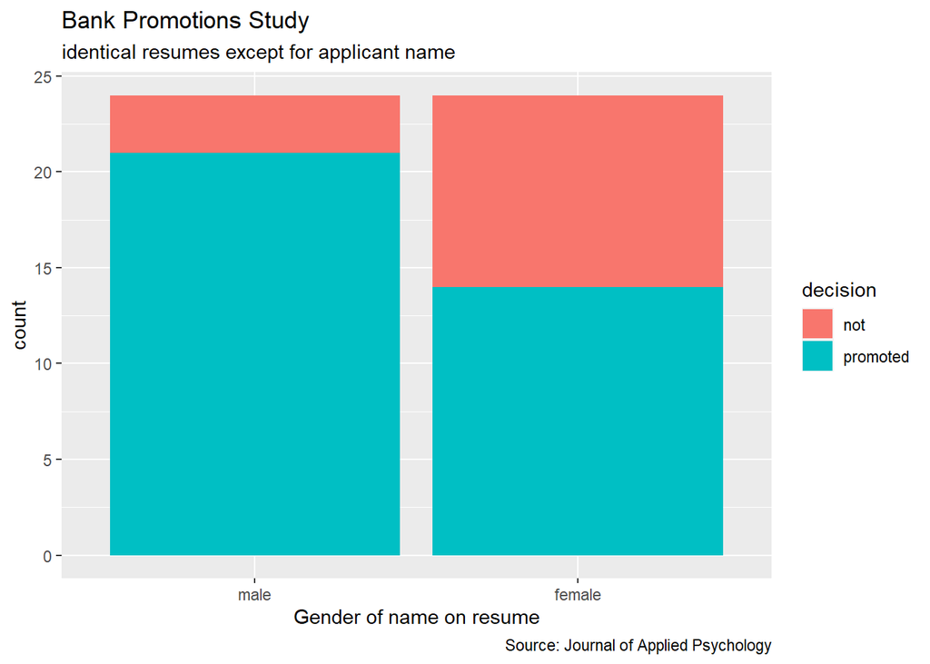

```r
ggplot(promotions, aes(x = gender, fill = decision)) +
  geom_bar() +
  labs(title = "Bank Promotions Study",
       subtitle = "identical resumes except for applicant name",
       caption = "Source: Journal of Applied Psychology",
       x = "Gender of name on resume")
```

```r
promotions %>%
  group_by(gender, decision) %>%
  tally()
```

```
## # A tibble: 4 × 3
## # Groups:   gender [2]
##   gender decision     n
##   <fct>  <fct>    <int>
## 1 male   not          3
## 2 male   promoted    21
## 3 female not         10
## 4 female promoted    14
```

- male promotion rate: 21/24 = 0.875
- female promotion rate: 14/24 = 0.583
- difference in rates: 0.875 - 0.583 = 0.292

## Shuffling

If `gender` did not matter when it comes to these job promotions, then it should not matter if we shuffle the `gender` labels in the data.

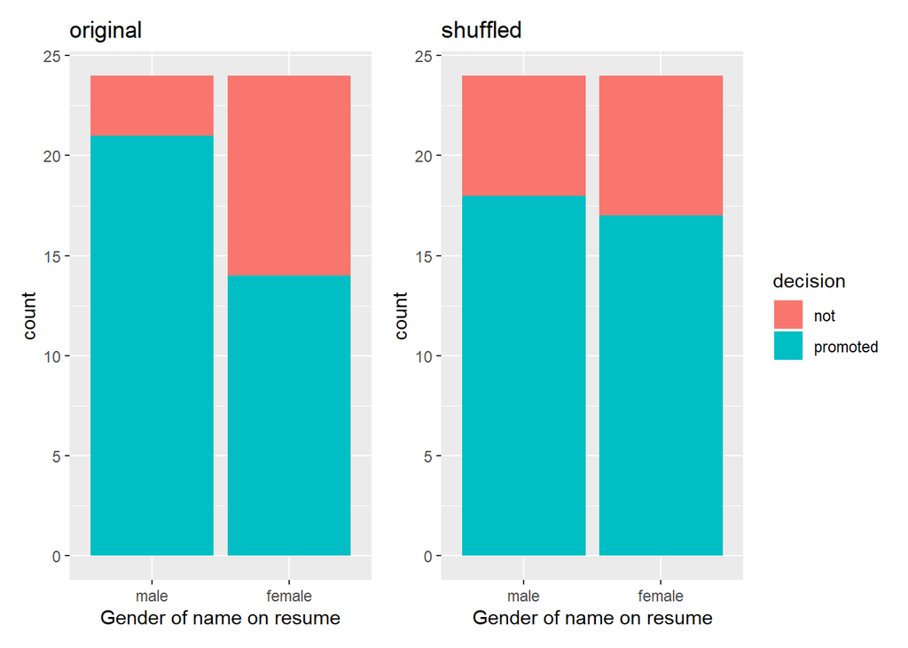

```r
original_bar_graph <- ggplot(promotions, aes(x = gender, fill = decision)) +
  geom_bar() +
  labs(title = "original",
       x = "Gender of name on resume") +
  theme(legend.position = "none")

gender_shuffled <- promotions
gender_shuffled$gender <- sample(promotions$gender)
#sampled without replacement

shuffled_bar_graph <- gender_shuffled %>%
  ggplot(aes(x = gender, fill = decision)) +
  geom_bar() +
  labs(title = "shuffled",
       x = "Gender of name on resume")

original_bar_graph + shuffled_bar_graph
```

- in the previous chapter, we did a *bootstrap method* that used sampling with replacement
- here, we are performing a *permutation test* that uses sampling without replacement

# Hypothesis Test of Proportions

1. “First, a *hypothesis* is a statement about the value of an unknown population parameter. In our resume activity, our population parameter is the difference in population proportions $p_{m} - p_{f}$”
2. “Second, a hypothesis test consists of a test between two competing hypotheses … Generally the *null hypothesis* is a claim that there really is ‘no effect’ or ‘no difference.’” Here our null hypothesis is
- $H_{0}$: men and women are promoted at the same rate

“Generally the *alternative hypothesis* is the claim the experimenter or researcher wants to establish or find evidence for and is viewed as a ‘challenger’ hypothesis to the null hypothesis”. Here our alternative hypothesis is

- $H_{a}$: men are promoted at a higher rate than women

In math symbols, we have

$$\begin{array}{rrcl}
H_{o}: p_{m} - p_{f} & = & 0 \\
H_{a}: p_{m} - p_{f} & > & 0 \\
\end{array}$$

3. “Third, a *test statistic* is a point estimate/sample statistic formula used for hypothesis testing, where a sample statistic is merely a summary statistic based on a sample of observations.” Here, our test statistic $\hat{p}_{m} - \hat{p}_{f}$ estimates the parameter of interest: the difference in population proportions $p_{m} - p_{f}$
4. “Fourth, the observed test statistic is the value of the test statistic that we observed in real-life.” In this example the observed difference was

$$\hat{p}_{m} - \hat{p}_{f} = 0.875 -
0.583 = 0.292$$

5. “Fifth, the null distribution is the sampling distribution of the test statistic assuming the null hypothesis $H_0$ is true.”

## Conducting a Hypothesis Test with `infer`

```r
promotions %>%
  specify(formula = decision ~ gender, success = "promoted")
```

```
## Response: decision (factor)
## Explanatory: gender (factor)
## # A tibble: 48 × 2
##    decision gender
##    <fct>    <fct>
##  1 promoted male
##  2 promoted male
##  3 promoted male
##  4 promoted male
##  5 promoted male
##  6 promoted male
##  7 promoted male
##  8 promoted male
##  9 promoted male
## 10 promoted male
## # ℹ 38 more rows
```

```r
promotions %>%
  specify(formula = decision ~ gender, success = "promoted") %>%
  # "point" for single sample or "independence" for two samples
  hypothesize(null = "independence")
```

```
## Response: decision (factor)
## Explanatory: gender (factor)
## Null Hypothesis: independence
## # A tibble: 48 × 2
##    decision gender
##    <fct>    <fct>
##  1 promoted male
##  2 promoted male
##  3 promoted male
##  4 promoted male
##  5 promoted male
##  6 promoted male
##  7 promoted male
##  8 promoted male
##  9 promoted male
## 10 promoted male
## # ℹ 38 more rows
```

```r
promotions_permutations <- promotions %>%
  specify(formula = decision ~ gender, success = "promoted") %>%
  hypothesize(null = "independence") %>%
  generate(reps = 1000, type = "permute")
```

```r
null_distribution <- promotions %>%
  specify(formula = decision ~ gender, success = "promoted") %>%
  hypothesize(null = "independence") %>%
  generate(reps = 1000, type = "permute") %>%
  calculate(stat = "diff in props", order = c("male", "female"))
```

```r
# observed difference in proportions
obs_diff_prop <- promotions %>%
  specify(decision ~ gender, success = "promoted") %>%
  calculate(stat = "diff in props", order = c("male", "female"))
obs_diff_prop
```

```
## Response: decision (factor)
## Explanatory: gender (factor)
## # A tibble: 1 × 1
##    stat
##   <dbl>
## 1 0.292
```

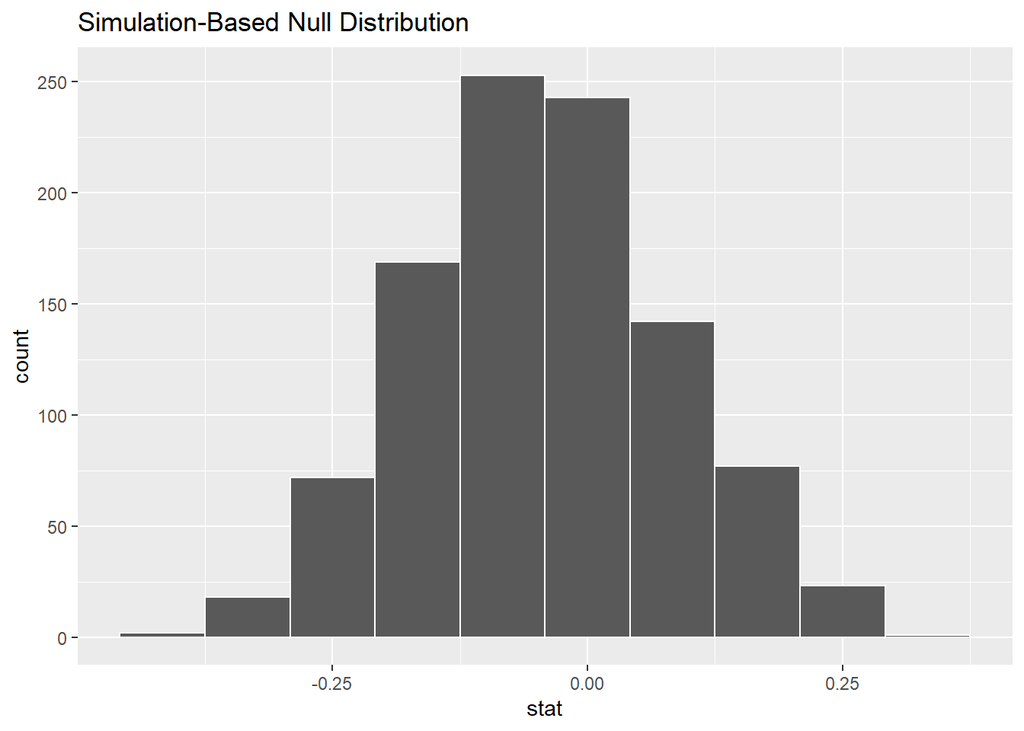

```r
visualize(null_distribution, bins = 10)
```

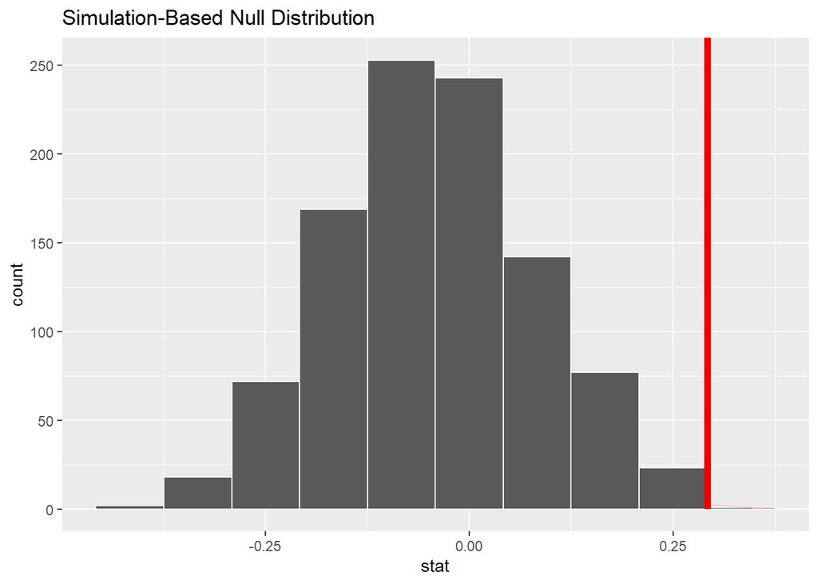

```r
visualize(null_distribution, bins = 10) +
  # choices for direction are "right", "left", and "both"
  shade_p_value(obs_stat = obs_diff_prop, direction = "right")
```

```r
null_distribution %>%
  get_p_value(obs_stat = obs_diff_prop, direction = "right")
```

```
## # A tibble: 1 × 1
##   p_value
##     <dbl>
## 1   0.024
```

For NHST (null hypothesis significance testing), many scientists compare the p-value to a significance level of $\alpha = 0.05$. Since the p-value < 0.05, we *reject the null hypothesis* of equal proportions of promotions among men and women.

## Comparision to Confidence Intervals

```r
bootstrap_distribution <- promotions %>%
  specify(formula = decision ~ gender, success = "promoted") %>%
  # Change 1 - Remove hypothesize():
  # hypothesize(null = "independence") %>%
  # Change 2 - Switch type from "permute" to "bootstrap":
  generate(reps = 1000, type = "bootstrap") %>%
  calculate(stat = "diff in props", order = c("male", "female"))
```

```r
percentile_ci <- bootstrap_distribution %>%
  get_confidence_interval(level = 0.95, type = "percentile")
percentile_ci
```

```
## # A tibble: 1 × 2
##   lower_ci upper_ci
##      <dbl>    <dbl>
## 1   0.0308    0.532
```

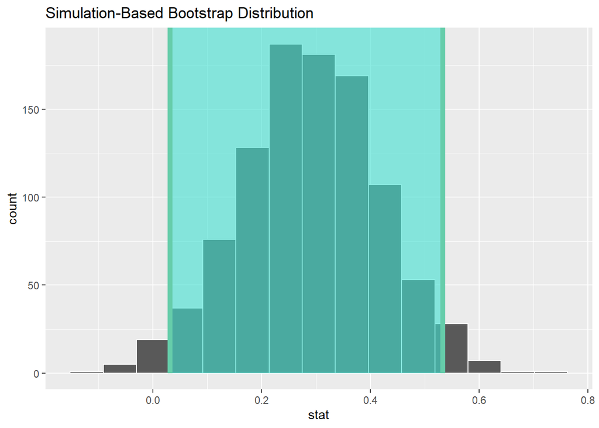

```r
visualize(bootstrap_distribution) +
  shade_confidence_interval(endpoints = percentile_ci)
```

# Demographics Examples

```r
# since the data is in a CSV file, we will use the read_csv() function to load the data
demo_df <- read_csv("demographics_survey_data.csv")

str(demo_df, give.attr = FALSE)
```

```
## spc_tbl_ [281 × 131] (S3: spec_tbl_df/tbl_df/tbl/data.frame)
##  $ enrolled            : chr [1:281] "Bio 18" "Bio 18" "Bio 18" "Bio 18" ...
##  $ home                : chr [1:281] "Southern California" "Northern California" "Southern California" "Central California" ...
##  $ ethnicity           : chr [1:281] "Hispanic or Latino" "Black or African American" "Asian or Pacific Islander" "Hispanic or Latino" ...
##  $ classStanding       : chr [1:281] "Junior" "Junior" "Junior" "Junior" ...
##  $ unitsCompleted      : num [1:281] 40 70 63 80 48 68 63 80 90 88 ...
##  $ unitsThisSemester   : num [1:281] 17 17 17 12 12 16 17 NA 13 16 ...
##  $ GPA                 : num [1:281] 3.1 3.25 3.61 3.4 2.5 ...
##  $ statsBefore         : chr [1:281] "Yes: Math 15 at UC Merced" "Yes: AP Statistics" "Yes: Math 15 at UC Merced" "Yes: another (other than Math 15) statistics training course at UC Merced" ...
##  $ retakingWithDerek   : chr [1:281] "No" "No" "No" "No" ...
##  $ learningStyle       : chr [1:281] "Visual" "Kinesthetic" "Kinesthetic" "Visual" ...
##  $ hoursStudying       : num [1:281] 3 12 4 4 6 5 10 NA 24 8 ...
##  $ birthdayMonth       : chr [1:281] "June" "January" "August" "December" ...
##  $ height              : num [1:281] 70 NA 63 68 55 59.5 66 NA 69 62 ...
##  $ shoeSize            : num [1:281] 11 8 8 8 4.5 6 10 NA 10 6 ...
```

[output cut: 86 more lines]

## Smart Phone Loyalty vs Class Standing

```r
# table(demo_df$classStanding)
# table(demo_df$smartPhones)
demo_df %>%
  filter(classStanding == "Sophomore" | classStanding == "Junior") %>%
  filter(smartPhones == "Android" | smartPhones == "iPhone") %>%
  group_by(classStanding, smartPhones) %>%
  summarize(classStanding = n())
```

```
## # A tibble: 4 × 2
## # Groups:   classStanding [4]
##   classStanding smartPhones
##           <int> <chr>
## 1            47 Android
## 2           118 iPhone
## 3            12 Android
## 4            23 iPhone
```

```r
# observed difference in proportions
obs_diff_prop <- demo_df %>%
  filter(classStanding == "Sophomore" | classStanding == "Junior") %>%
  filter(smartPhones == "Android" | smartPhones == "iPhone") %>%
  specify(smartPhones ~ classStanding, success = "iPhone") %>%
  calculate(stat = "diff in props", order = c("Sophomore", "Junior"))
obs_diff_prop
```

```
## Response: smartPhones (factor)
## Explanatory: classStanding (factor)
## # A tibble: 1 × 1
##      stat
##     <dbl>
## 1 -0.0580
```

```r
null_distribution <- demo_df %>%
  filter(classStanding == "Sophomore" | classStanding == "Junior") %>%
  filter(smartPhones == "Android" | smartPhones == "iPhone") %>%
  specify(smartPhones ~ classStanding, success = "iPhone") %>%
  hypothesize(null = "independence") %>%
  generate(reps = 1000, type = "permute") %>%
  calculate(stat = "diff in props", order = c("Sophomore", "Junior"))
```

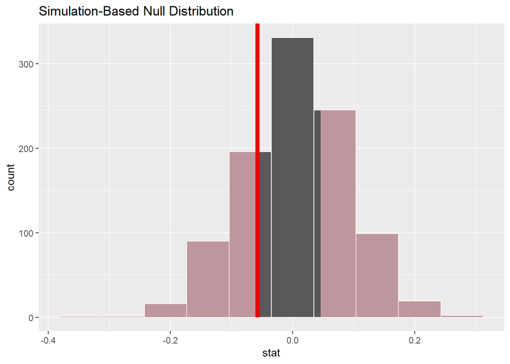

```r
visualize(null_distribution, bins = 10) +
  shade_p_value(obs_stat = obs_diff_prop, direction = "two_sided")
```

```r
null_distribution %>%
  get_p_value(obs_stat = obs_diff_prop, direction = "two_sided")
```

```
## # A tibble: 1 × 1
##   p_value
##     <dbl>
## 1   0.608
```

# Exercises

## Procrastination vs Partying

The survey questions were

- “Do you consider yourself to be a procrastinator?”
- “Do you plan to attend at least one party per month this semester?”
- colloquial hypothesis: Party goers are more likely to be procrastinators
- null hypothesis: Procrastinator proportion is the same regardless of party going plans
- alternative hypothesis: Party goers are more likely to be procrastinators
- predictor variable (categorical): `parties`
- response variable (categorical): `procrastinator`

In this scenario, our one-sided hypothesis test looks at a difference of two proportions.

$$\begin{array}{rrcl}
H_{0}: p_{Y} - p_{N} & = & 0 \\
H_{a}: p_{Y} - p_{N} & > & 0 \\
\end{array}$$

1. Compute the observed difference in proportions for the procrastination grouped by parties

```r
# table(demo_df$procrastinator)
# table(demo_df$parties)
```

2. Build a null distribution toward the hypothesis test.
3. Use the `visualize` function to graph the null distribution and shade the p-value.
4. Compute the p-value for the hypothesis test, and then write a sentence to describe the conclusion of the hypothesis test.